# Question 2: Book formats and number of sheets over time

Authors: Michael Falk, Rachel Hendery, Katie McDonough

# The questions

In order to study the STN’s use of paper, it is useful to know how many books of what kind they were producing at any given time. There are two main questions we’d like to try and answer:

- How much paper was going into the STN’s books in any given year?
- Did the mixture of different formats change over time?

To get started, the cell below loads the necessary libraries for this notebook.

```r
library(DBI)
library(RMySQL)
library(tidyverse)
library(magrittr)
library(scales)
```

# The data

The data we have to draw on comes from the STN’s account books. We have a catalogue of all the books they produced between 1770 and 1794. And we have a comprehensive archive of all their sales through this period. (There’s plenty of other data too, but this is what is relevant to the questions of this notebook.)

To get started, we can load the catalogue of books.

```r
# Create connection object
manuscripts <- dbConnect(MySQL(), user="root", dbname="manuscripts", host="localhost")
# Import editions table
editions <- manuscripts %>%
  dbSendQuery("SELECT * FROM books") %>%
  fetch(n = Inf) %>%
  as_tibble()
```

Let’s have a look at the data:

```r
editions
```

| book_code | super_book_code | edition_status | edition_type | full_book_title | short_book_titles | translated_title | translated_language | languages | stated_publishers | actual_publishers | stated_publication_places | actual_publication_places | stated_publication_years | actual_publication_years | pages | quick_pages | number_of_volumes | section | edition | book_sheets | notes | research_notes |
| --- | --- | --- | --- | --- | --- | --- | --- | --- | --- | --- | --- | --- | --- | --- | --- | --- | --- | --- | --- | --- | --- | --- |
| bk0000003 | spbk0002530 | Certain | French editions | Abrégé de l'Histoire générale des voyages, contenant ce qu'il y a de plus remarquable, de plus utile et de mieux avéré dans les pays où les voyageurs ont pénétré; les moeurs des habitans, la religion,… | Abrégé de l'histoire des voyages; abregé de l'histoire generale des Voyages; Abrégé des voyages | NA | NA | French | Hôtel de Thou | NA | Paris | Paris | 1780-1786 | NA | NA | NA | 23 | NA | 8 | 2220 | NA | Attribution - only located extant edition at the time it appeared in STN accounts. |
| bk0000005 | spbk0002548 | Pseudo | Place of publication unknown | Almanach des muses | almanac des Muses; almanach des muses | NA | NA | French | NA | NA | n.pl. | ? | NA | NA | NA | NA | 1 | NA | NA | 244 | NA | Attribution - periodical, unidentified volumes. |
| bk0000006 | spbk0002557 | Pseudo | Place of publication unknown | Art (l') de peindre sur l'émail | art de peinture en email | NA | NA | French | NA | NA | n.pl. | ? | NA | NA | NA | NA | 1 | NA | NA | NA | NA | Attribution - posthumous work published in 1765 with 'Traité des couleurs pour la peinture en émail et sur la porcelaine', but no extant copy of the work in isolation has been located. |
| bk0000007 | spbk0003976 | Pseudo | Place of publication unknown | Apparat royal, dictionnaire françois et latin, enrichi des meilleures expressions en l'une & l'autre langue, & mis dans un ordre très-facile & très-méthodique | Apparat royal; apparral royal | NA | NA | French | NA | NA | n.pl. | ? | NA | NA | NA | NA | 1 | NA | 8 | 57 | NA | Attribution - MS1007 and catalogue information show that STN traded in a (Lyon, 1767) edition, although extant copies of this edition have not been located, and the STN traded in other editions as wel… |
| bk0000010 | spbk0002545 | Pseudo | Place of publication unknown | Nouvelle (la) Académie des dames, ou histoire de Mlle B*** D. C. D. L. | academie des Dames, nouvelles; Nouvelle académie; nouvelle académie des Dames; Nouvelle Académie des Dames ou Histoire de Mlle B*** D. C. D. L. | NA | NA | French | NA | NA | n.pl. | ? | NA | NA | NA | NA | 1 | NA | NA | 13 | NA | Attribution - edition not identified, several produced. STN sold work in-12° and in-8° editions. First published as 'Histoire de Mademoiselle Brion, dite comtesse de Launay'. |
| bk0000014 | spbk0000238 | Probable | French editions | Boulevard (le) des Chartreux, poeme chrétien | Boulevard des Chartreux | NA | NA | French | NA | NA | Grenoble | Grenoble | 1779 | NA | 34 | 34 | 1 | NA | NA | 10 | NA | Attribution - only extant edition located. |
| bk0000015 | spbk0000239 | Certain | STN editions | Réponse du sieur Bourboulon... au Compte rendu au roi par M. Necker, directeur général des finances | Bourboulon | NA | NA | French | NA | Société Typographique de Neuchâtel | London | Neuchâtel | 1781 | NA | NA | NA | 1 | NA | NA | NA | P | Attribution - only extant edition located. STN transactions data shows that this a previously unknown STN edition. Manuscript information gives only 'Bourboullon'. |
| bk0000021 | spbk0000284 | Pseudo | Place of publication unknown | [Cathéchisme de Zürich] | Cathechisme (grand) de Zurick | NA | NA | French | NA | NA | n.pl. | ? | NA | NA | NA | NA | 1 | NA | NA | 10 | NA | Attribution - work not identified. |
| bk0000022 | spbk0000287 | Pseudo | Place of publication unknown | [Catéchisme de Roques] | Cathechisme de Roques | NA | NA | French | NA | NA | n.pl. | ? | NA | NA | NA | NA | 1 | NA | NA | 7 | NA | Attribution - work not identified. |
| bk0000023 | spbk0000405 | Certain | Dutch editions | Contes moraux, par Mde Le Prince de Beaumont | Contes de Beaumont; Contes nouveaux de Beaumont | NA | NA | French | J.-E. Dufour | NA | Maestricht | Maestricht | 1774 | NA | NA | NA | 2 | NA | 12 | 36 | NA | Attribution - sourced from Dufour and catalogue information. |

[output cut: 990 more lines]

Since we want to know how much paper the STN was using, we are only interested in the books they actually produced during this period. There are several thousand books in the catalogue, because the STN also dealt in other people’s books. The next cell filters out the rows of `editions` that we want.

```r
# The editions have all been categorised. Three of these categories entail that the STN actually manufactured the book.
stn_edition_types <- c("STN editions", "Livres en Société: STN joint editions", "Commissioned STN edition")
stn_editions <- editions %>%
  filter(edition_type %in% stn_edition_types)
```

Now we have a data frame (actually a `tibble`) of the books the STN produced during the study period. They apparently published 247 different `editions` of various books during the study period.

## How many sheets of paper were used to make each book?

Because [book size](https://en.wikipedia.org/wiki/Book_size) was so standardised in the eighteenth century, this is actually a simple question conceptually. Books were nearly always made from sheets of the standard ‘folio’ size, which were then folded 1, 2, 4 or 6 times, to produce the four most common sizes of book. Book formats were defined by the number of leaves into which the sheet was divided. If the sheet was folded once, this would prouduce 2 ‘leaves’, each of which could be printed on both sides to produce 4 pages of text. This is a ‘folio’ or ‘in-2’ edition. Similarly, a ‘quarto’ edition was folded twice to produce *4* leaves, an ‘octavo’ eidiotn was folded 4 times to produce *8* leaves, and a duodecimo edition was folded 6 times to produce *12* leaves. In the STN data, the number of leaves and the total pages have been recorded for every `edition` where the information was available. We shoudl therefore be able to calculate the number of sheets of paper required to fabricate each edition using the following formula:

$$sheets = \lceil \frac{pages} {2 \times leaves} \rceil$$

This calculation may not be wholly accurate for all the books in the data, because some were in multiple volumes and the pages may be concatenated by our approach. This is not a big problem, however, because it would only result in our sheet estimates being 1 or possibly 2 sheets too low for any given book. The multi-volume books in question comprise dozens or even hundreds of sheets, so this difference really is negligible.

The next cell defines a function for extracting the number of pages from the page number data in the database. Unfortunately the page number data has been stored as a string, and some of the numbers are expressed in roman numerals. We need to massage this data using regular expressions to get the numbers we need.

You can see a random record as an example:

```r
stn_editions %>% select(pages) %>% drop_na() %>% sample_n(1) %>% as.character()
```

```
[1] "XXX, 344; [2], 355, [1 bl.]"
```

The next cell defines a function, `sum_pages`, that will examine string like the one above, extract any numbers (whether hindu-arabic or roman), and then sum them together to calculate the total number of pages for a given `edition`.

```r
sum_pages <- function(pages) {
  #############
  #
  # Given a character vector of page number information, this finds any Roman or
  # Hindu-Arabic numerals and sums them.
  #
  # depends:
  #   stringr (part of the tidyverse)
  #
  # params:
  #   pages: a character vector
  #
  # returns:
  #   num_pages: the total pages
  #
  #############

  require(stringr)

  # Search for roman numerals
  rom_reg <- regex("
                  (?<!b)    # do not find a match if there is a 'b' in front ('bl.' = 'blank')
                  [ivxlcdm]+  # look for any number of the roman numerals
                   ", comments = T,
                   ignore_case = T)
  roman <- str_match_all(pages, rom_reg)

  # roman is a list with a column vector of strings for each book
  roman <- lapply(roman, as.roman) # interpret all roman numerals using built in R function
  roman_totals <- sapply(roman, sum) # then sum all the results

  # now extract hindu-arabic numerals
  hindu_arabic <- str_match_all(pages, "\\d+")
  hindu_arabic_totals <- sapply(hindu_arabic, function(x) sum(as.numeric(x)))

  # add these two amounts to get the total pages for each book
  num_pages <- roman_totals + hindu_arabic_totals

  return(num_pages)
}
```

Now that we have defined that helper function, we can apply it to our data to add columns for `total_pages` and `total_sheets`. The number of folds for each edition is stored in the `edition` column. Below the following cell you can examine 5 random examples of the results.

```r
stn_editions %<>%
  mutate(
    # First let's get the format of each book as a number:
    edition = str_replace(edition, "Folio", "2"), # replace the word 'folio' with the number of leaves
    edition = as.integer(edition),
    # Next let's get the total pages according to the 'pages' column (which seems to be the most accurate)
    total_pages = sum_pages(pages),
    # Now let's estimate the number of sheets according to the total_pages and the format
    # NB: this is the total number of sheets across all volumes of the book
    total_sheets = total_pages / (2 * edition),
    # This should be rounded up to the nearest whole number, on the assumption that parts of sheets were not reused.
    total_sheets = ceiling(total_sheets)
  )
stn_editions %>%
  select(book_code, pages, edition, total_pages, total_sheets, full_book_title) %>%
  sample_n(5)
```

| book_code | pages | edition | total_pages | total_sheets | full_book_title |
| --- | --- | --- | --- | --- | --- |
| bk0002418 | IV, 148 | 8 | 152 | 10 | Mizrim, ou Le sage à la cour: histoire égyptienne |
| bk0002066 | XLIII, [1], 209, [3 bl.] | 8 | 256 | 16 | Destruction (la) de la ligue, ou La réduction de Paris |
| bk0001967 | [4], 396; [4], 423, [1 bl.]; [4], 390, [2 bl.]; [4], 382, [2 bl.] | 8 | 1612 | 101 | Mon Bonnet de nuit |
| bk0001934 | 8 | 4 | 8 | 1 | Architecture hydraulique. Canal des deux mers, par M. de La Roche |
| bk0000954 | [4], 136 | 8 | 140 | 9 | Observations sur la constitution militaire et politique des armées de S.M. prussienne: avec quelques anecdotes de la vie privée de ce monarque |

## How many books did the STN produce?

We do not have any direct figures for how many books the STN produced in a given year. Instead, what we know is how many books they were selling or receiving at any particular moment in time. The following cell imports the transaction data from the database. Each `order` in the database is a single event in time, which comprises many `transactions`, or exchanges of particular titles. To estimate how many books the STN were producing, we will focus only on `out` transactions of their own `editions`. To work out how many sheets of paper were required to meet each order, we can multiply the number of copies sold by the number of sheets required to produce each copy.

NB: The transaction data actually gives the `number_of_volumes`, not the number of copies sold. So a sale of 300 volumes of a 3-volume work would correspond to a sale of 100 copies of that `edition`. We do have some fine-grained data on which particular volumes were traded, but it may not be worth the effort to calculate how many sheets each volume of each edition contained or to make the necessary data join. This is because, as noted above, the page numbers per volume are currently stored as unstructured data.

```r
orders <- manuscripts %>%
  dbSendQuery("SELECT * FROM orders") %>%
  fetch(n = Inf) %>%
  as_tibble()
transactions <- manuscripts %>%
  dbSendQuery("SELECT * FROM transactions") %>%
  fetch(n = Inf) %>%
  as_tibble() %>%
  filter(str_detect(direction_of_transaction, regex("out", ignore_case = T))) %>% # only want books sent out/sold.
  rename(num_vols_exchanged = total_number_of_volumes) %>% # rename this confusing column
  mutate(num_vols_exchanged = abs(num_vols_exchanged)) %>% # all out transactions are negative numbers
  right_join(orders, by = "order_code") %>% # add order time (time, location etc. of transaction)
  mutate(order_year = as.numeric(str_extract(date, "\\d{4}"))) %>% # extract year of order from date column
  right_join(stn_editions, by = "book_code") %>% # add book information to the transaction data. The right join drops rows for non-STN editions.
  mutate(sheets_needed = num_vols_exchanged / number_of_volumes * total_sheets) %>% # calculate total sheets for each transaction
  select(transaction_code, book_code, full_book_title, total_pages, edition, total_sheets, number_of_volumes, num_vols_exchanged, sheets_needed, everything()) # reorder columns
```

Now we have all the data we need to assess the STN’s paper usage in the study period.

# Discussion

## How many sheets did they use per year?

We can estimate the number of sheets used per year by summing all the orders for each year:

```r
yearly_data <- transactions %>%
  group_by(order_year) %>%
  summarise(sheets_needed = sum(sheets_needed, na.rm = T)) %>%
  drop_na()
yearly_data
```

| order_year | sheets_needed |
| --- | --- |
| 1770 | 186988.28 |
| 1771 | 347058.22 |
| 1772 | 501301.28 |
| 1773 | 988714.61 |
| 1774 | 275190.56 |
| 1775 | 345988.49 |
| 1776 | 249001.70 |
| 1777 | 294242.34 |
| 1778 | 342131.22 |
| 1779 | 592911.39 |

[output cut: 14 more lines]

It is convenient to visualise this data in a line graph:

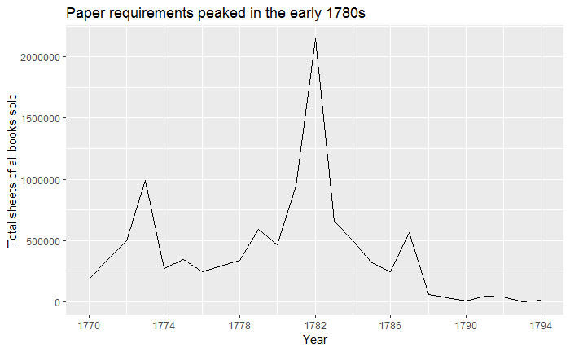

```r
yearly_data %>%
  ggplot(aes(order_year, sheets_needed)) +
  geom_line() +
  scale_x_continuous(breaks = seq(1770, 1794, by = 4)) +
  labs(
    x = "Year",
    y = "Total sheets of all books sold",
    title = "Paper requirements peaked in the early 1780s"
  )
```

From 1770 until the eve of the French Revolution, the STN required on average 554013 sheets of paper each year to meet its demand for books. From 1788 onwards, the demand suddenly dropped, and mean paper requirements were only 28443 sheets per year on average.

## How reliable are these estimates?

The data is not perfect. ‘Out’ transactions are only a proxy for the number of book the STN actually produced, and books produced is only a proxy for the amount of paper they would actually need. A book may be produced, and then remaindered, and the paper could conceivably be pulped and reused for a later edition.

A bigger problem is that we do not know the format of all the STN’s editions, so the above graph only displays a subset of the data. Of the 247 editions in the dataset, we know the format of 186, or 75.3% of them. Of course, different editions sold in different amounts, so this lack of information may or may not be a serious problem. Looking at the transaction data, we can see that of the 598965 volumes sold in the period, we know the format of 438883, or 73.27%.

```r
stn_editions %>% filter(is.na(total_sheets))
```

| book_code | super_book_code | edition_status | edition_type | full_book_title | short_book_titles | translated_title | translated_language | languages | stated_publishers | actual_publishers | stated_publication_places | actual_publication_places | stated_publication_years | actual_publication_years | pages | quick_pages | number_of_volumes | section | edition | book_sheets | notes | research_notes | total_pages | total_sheets |
| --- | --- | --- | --- | --- | --- | --- | --- | --- | --- | --- | --- | --- | --- | --- | --- | --- | --- | --- | --- | --- | --- | --- | --- | --- |
| bk0000015 | spbk0000239 | Certain | STN editions | Réponse du sieur Bourboulon... au Compte rendu au roi par M. Necker, directeur général des finances | Bourboulon | NA | NA | French | NA | Société Typographique de Neuchâtel | London | Neuchâtel | 1781 | NA | NA | NA | 1 | NA | NA | NA | P | Attribution - only extant edition located. STN transactions data shows that this a previously unknown STN edition. Manuscript information gives only 'Bourboullon'. | NA | NA |
| bk0000069 | spbk0002947 | Certain | STN editions | Cours abrégé de géographie historique, ancienne & moderne, et de sphère: par demandes & réponses. Quatrième édition, revue, corrigée et augmentée par l'auteur | Geographie historique | NA | NA | French | Société Typographique de Neuchâtel | NA | Neuchâtel | Neuchâtel | 1774 | NA | NA | NA | 2 | NA | NA | NA | NA | Attribution - known STN edition. The STN published editions of both the 'Cours abrégé de géographie historique' and the 'Cours abrégé de géographie élémentaire' in 1770 (when they printed both a combi… | NA | NA |
| bk0000070 | spbk0002948 | Certain | STN editions | Géographie élémentaire. Quatrième édition | Abrégé de géographie; abrégé de la géographie; Cours de géographie; Cours de géographie élémentaire par demandes et réponses par M. Ostervald; Geographie elementaire | NA | NA | French | Société Typographique de Neuchâtel | NA | Neuchâtel | Neuchâtel | 1774 | NA | NA | NA | 1 | NA | NA | NA | NA | Attribution - known STN edition. The STN published editions of both the 'Cours abrégé de géographie historique' and the 'Cours abrégé de géographie élémentaire' in 1770 (when they printed both a combi… | NA | NA |
| bk0000091 | spbk0001296 | Pseudo | STN editions | Jeu (le) des trois sept | 682; Jeux des 3 Sept | NA | NA | French | NA | Société Typographique de Neuchâtel? | n.pl. | Neuchâtel? | NA | NA | NA | NA | 1 | NA | 12 | 1 | NA | Attribution - work not identified. Traded by STN under accounting heading 'nos editions'. Fauche-Borel Catalogue (1787) (gives only title and in-12°). Presumably a reprint of the rules of the card gam… | NA | NA |
| bk0000094 | spbk0001272 | Certain | Livres en Société: STN joint editions | Introduction à la connaissance géographique et politique des Etats de l'Europe | 712; Introduction … la Geographie de Bushing; Introduction à la géographie; Introduction à la géographie de Bushing; Introduction de Bushing | Vorbereitung zur grundlichen und nützlichen Kenntniss der geographischen Beschaffenheit | German | French | Libraires associés | Société Typographique de Neuchâtel | En Suisse | Neuchâtel | 1779 | NA | NA | NA | 1 | NA | 8 | 11 | NA | Attribution - known confédération edition printed by the STN, catalogue information. Edition has not been located. | NA | NA |
| bk0000152 | spbk0001888 | Pseudo | STN editions | Recueil des passages du Nouveau Testament qui servent à établir les vérités et les devoirs de la religion chrétienne | 1161; passages; Recueil de pasages de l’E.S; Recueil des passages | NA | NA | French | Société Typographique de Neuchâtel | NA | Neuchâtel | Neuchâtel | 1770-1774 | NA | NA | NA | 1 | NA | NA | NA | NA | Attribution - this STN probably produced editions of this work in 1770 (see Schmidt 'liste des editions') and 1774 (see Fauche-Borel Catalogue 1787 - in-12°, Neuchâtel, 1774). However, they appear to … | NA | NA |
| bk0000363 | spbk0004067 | Certain | Livres en Société: STN joint editions | Découverte (la) de l'Amérique: pour l'instruction et l'amusement des jeunes gens, par Mr. Campe; avec figures | 266; Decouvertes de l'Amerique | Die Entdeckung von Amerika, ein angenehmes und nützliches Lesebuch für Kinder und junge Leute | German | French | Libraires associés | Société Typographique de Berne | En Suisse | Berne | 1784-1785 | NA | NA | NA | 3 | NA | 12 | NA | NA | Attribution - sourced from Société Typographique de Berne in 1785, catalogue information. Known confederation edition. | NA | NA |
| bk0000920 | spbk0000497 | Certain | STN editions | Descriptions des arts et métiers, faites ou approuvées par Messieurs de l'Académie royale des sciences de Paris | 279; Description des arts; Description des Arts et Metiers; Dictionnaire des arts | NA | NA | French | Société Typographique de Neuchâtel | NA | Neuchâtel | Neuchâtel | 1771-1783 | NA | NA | NA | 19 | NA | 4 | NA | NA | Attribution - known STN edition. N.B. Along with the ‘Encyclopédie’, the STNs edition of the ‘Descriptions des Arts’ was a lengthy and complicated undertaking that, largely due to subscription sales, … | NA | NA |
| bk0001215 | spbk0002967 | Pseudo | STN editions | Henri IV, drame lyrique en 3 actes et en prose, par M. de Rozoy | Henri IV drame lyrique en 3 actes & en prose; Henry IV; henry le grand | NA | NA | French | NA | Société Typographique de Neuchâtel | n.pl. | Neuchâtel | 1775 | NA | NA | NA | 1 | NA | 8 | NA | NA | Attribition - previously unknown STN edition, although this edition has not been located. | NA | NA |
| bk0001292 | spbk0000962 | Certain | Livres en Société: STN joint editions | Maître de la langue allemande ou nouvelle Grammaire allemande... composée sur le modèle des meilleurs auteurs de nos jours et principalement sur celui de M. le Prof. Gottsched | 835; Gottshed; Grammaire de Gaudsched; Grammaire de Gottshed; Maitre allemande | Grundlegung einer deutschen Sprachkunst? | German | French | aux Dépens de la Société | Société Typographique de Berne; Société Typographique de Neuchâtel | En Suisse | Berne; Neuchâtel | 1781 | NA | NA | NA | 1 | NA | NA | 35 | NA | Attribution - edition details not entirely resolved. Known 'confédération' edition; Fauche-Borel Catalogue (1787) gives Strasbourg, 1786. | NA | NA |

[output cut: 51 more lines]

For 17 of these 61 titles without sufficient page or format data, we have a manually entered sheets estimate in the `book_sheets` column. One partial solution would be to incorporate this data into our estimates. Another option would be to assume that these 61 titles come from the same distribution as the others. That is to say, we could assume that these titles were published in a simlar mixture of formats and had a similar number of pages on average to the rest of the titles in the data.

I believe that the unknown books come from the same distribution as the known books. That is, we can assume for the sake of our estimates the the 61 unknown books had similar formats, similar page numbers, and similar sales figures to the other books. This is because there is a correlation in the data between the number of volume traded and the number of sheets required. This is true even though we know the number of volumes traded for all but 3 of the 17886 sales in the data.

```r
sheets_v_volumes <- transactions %>%
  group_by(order_year) %>%
  summarise(sheets_needed = sum(sheets_needed, na.rm = T),
            num_vols_exchanged = sum(num_vols_exchanged, na.rm = T)) %>%
  drop_na() %>%
  mutate_at(2:3, log) # convert to log scale

# There is an extremely strong correlation:
sheet_vol_cor <- cor.test(sheets_v_volumes$sheets_needed, sheets_v_volumes$num_vols_exchanged, method = "pearson", alternative = "greater")
```

This test find a Pearson’s product-moment correlation coefficient of 0.9534984 with a p-value < 910^{-14}. I have calculated the correlation coefficient on the log scale, because it is at this scale the the data appears to be normally distributed (which is a precondition for Pearson’s coefficient to adequately capture the variation in the data). See the cell and graph below.

```r
transactions %>%
  select(sheets_needed, num_vols_exchanged) %>%
  mutate_all(log) %>%
  gather(metric, score) %>%
  drop_na() %>%
  ggplot(aes(score)) +
  facet_wrap(~metric) +
  geom_histogram(bins = 40) +
  labs(
    title = "The two distributions are roughly normal on the log scale.",
    subtitle = "Number of volumes exchanged and sheets needed per transaction.",
    x = "Natural logarithm of volumes (left) or sheets (right)"
  )
```

[output not shown]

The correlation is evident on the below scatterplot, which is again shown at the log scale:

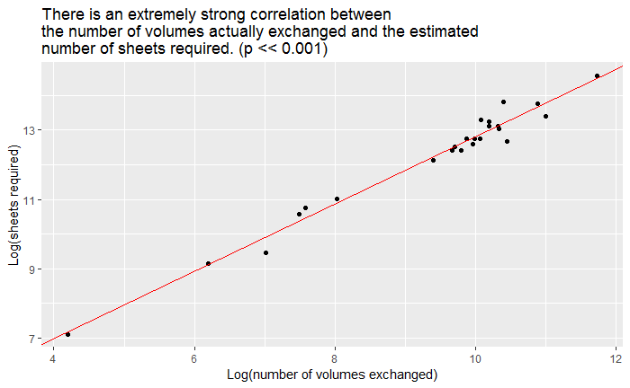

```r
# This is obvious from the graph:
model <- lm(sheets_v_volumes$sheets_needed ~ sheets_v_volumes$num_vols_exchanged)
sheets_v_volumes %>%
  ggplot(aes(num_vols_exchanged, sheets_needed)) +
  geom_point() +
  geom_abline(intercept = model$coefficients[1], slope =  model$coefficients[2], colour = "red") +
  labs(
    title = paste0(
      "There is an extremely strong correlation between\n",
      "the number of volumes actually exchanged and the estimated\n",
      "number of sheets required. (p << 0.001)"
    ),
    x = "Log(number of volumes exchanged)",
    y = "Log(sheets required)"
  )
```

Thus statistical analysis suggests that the trends we have observed are actually true. We can safely argue that paper needs increased in the 1780s and fell in the wake of the French Revolution.

From a broader economic and historial perspective, it seems reasonable to make another generalisation, and to argue that the unknown books required a similar amount of paper to make as the known books. This is because the cost of books varied according to their format in this period. Moreover, books were a highly-traded commoditiy and generally speaking a luxury item. Demand for them was therefore probably elastic to price. Therefore, if the format varied, so did the price, and if the price varied, so did the demand. (We could do some research to test this theory.) Another way of putting this is that the demand for books depended on their size and format. Now the books whose format we do know traded in a similar mixture of formats from year to year. This suggests that the market wanted a similar mixture of books even if their demand for books overall rose or fell. Meanwhile, the demand for the 61 books whose format we don’t know rose and fell along with the demand for the known books. If the demand for them moved up and down in the same way, and the market tended to want the same mixture of formats year-on-year, it stands to reason that the unknown books were published in a similar range of formats and prices to the rest of the books.

If my hypothesis is correct, then we can update our estimate of the number of sheets required each year by estimating the average requirements for the unknown books. To do this, we can simply divide `total_sheets_required` by the percentage of titles whose sheet requirements we know for that year.

The following cell calculates the percentage of volumes for which we know the number of sheets for each year. As can bee seen from the table, there are several years where our knowledge is quite incomplete.

```r
num_known <- transactions %>%
  mutate(sheets_known = !is.na(total_sheets),
         known_vols = num_vols_exchanged * sheets_known) %>%
  group_by(order_year) %>%
  summarise(known_vols = sum(known_vols, na.rm = T)/sum(num_vols_exchanged, na.rm = T)) %>%
  drop_na()
num_known
```

| order_year | known_vols |
| --- | --- |
| 1770 | 0.7541379 |
| 1771 | 0.7108975 |
| 1772 | 0.8625033 |
| 1773 | 0.7447856 |
| 1774 | 0.7400317 |
| 1775 | 0.8406251 |
| 1776 | 0.8199187 |
| 1777 | 0.7196161 |
| 1778 | 0.8378565 |
| 1779 | 0.8069684 |

[output cut: 14 more lines]

The following cell revises our estimates of the sheets required according to the method I have described.

```r
yearly_data %<>%
  left_join(num_known) %>%
  mutate(revised = sheets_needed / known_vols)
yearly_data
```

| order_year | sheets_needed | known_vols | revised |
| --- | --- | --- | --- |
| 1770 | 186988.28 | 0.7541379 | 247949.715 |
| 1771 | 347058.22 | 0.7108975 | 488197.251 |
| 1772 | 501301.28 | 0.8625033 | 581216.656 |
| 1773 | 988714.61 | 0.7447856 | 1327515.721 |
| 1774 | 275190.56 | 0.7400317 | 371863.198 |
| 1775 | 345988.49 | 0.8406251 | 411584.758 |
| 1776 | 249001.70 | 0.8199187 | 303690.726 |
| 1777 | 294242.34 | 0.7196161 | 408887.961 |
| 1778 | 342131.22 | 0.8378565 | 408341.095 |
| 1779 | 592911.39 | 0.8069684 | 734739.314 |

[output cut: 14 more lines]

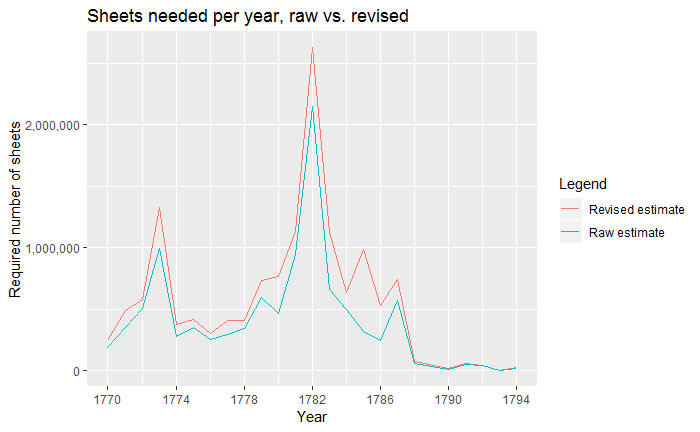

```r
yearly_data %>%
  select(-known_vols) %>%
  gather(metric, measure, -order_year) %>%
  ggplot(aes(order_year, measure, color = metric)) +
  geom_line() +
  scale_y_continuous(labels = comma) +
  scale_x_continuous(breaks = seq(1770, 1794, by = 4)) +
  scale_color_discrete(labels = c("Revised estimate", "Raw estimate")) +
  labs(
    title = "Sheets needed per year, raw vs. revised",
    x = "Year",
    y = "Required number of sheets",
    colour = "Legend"
  )
```

## Did the format of the books sold vary year on year?

The above statistical analysis suggests that the overall mixture of different formats did not vary considerably year-on-year. Generally speaking, the same number of sheets was required in order to produce a given number of volumes. But this does not necessarily mean that the STN produced exactly the same ratio of folios to quartos to octavos every year. Perhaps the demand for different formats were linked to one another, so that a year where more quartos were sold would be a year when less octavos were sold, because there was a fixed overall demand the roughly corresponded to the number of sheets.

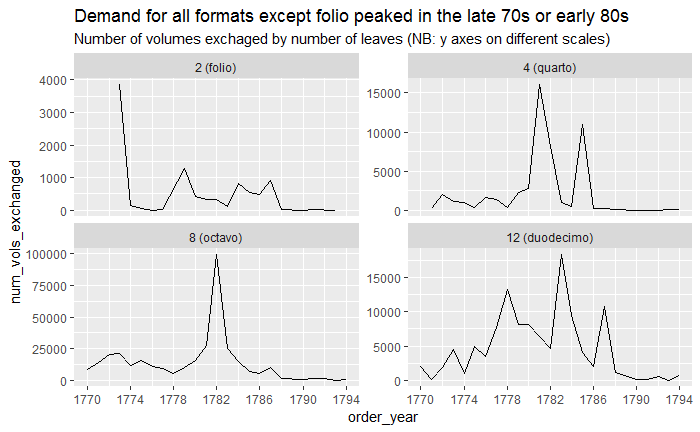

```r
# Or a faceted lined graph
format_labeller = as_labeller(c(
  "2" = "2 (folio)",
  "4" = "4 (quarto)",
  "8" = "8 (octavo)",
  "12" = "12 (duodecimo)"
  ))
transactions %>%
  filter(!is.na(edition)) %>%
  group_by(order_year, edition) %>%
  summarise(num_vols_exchanged = sum(num_vols_exchanged)) %>%
  ggplot(aes(order_year, num_vols_exchanged)) +
  facet_wrap(~edition, scales = "free_y", labeller = format_labeller) +
  scale_x_continuous(breaks = seq(1770, 1794, by = 4)) +
  geom_line() +
  labs(
    title = "Demand for all formats except folio peaked in the late 70s or early 80s",
    subtitle = "Number of volumes exchaged by number of leaves (NB: y axes on different scales)"
  )
```

The cell below tries a different kind of visualisation:

| order_year | edition | num_vols_exchanged |
| --- | --- | --- |
| 1770-74 | 2 | 3988 |
| 1770-74 | 4 | 4401 |
| 1770-74 | 8 | 76637 |
| 1770-74 | 12 | 9494 |
| 1770-74 | Unknown | 12553 |
| 1775-79 | 2 | 1354 |
| 1775-79 | 4 | 6036 |
| 1775-79 | 8 | 51811 |
| 1775-79 | 12 | 37396 |
| 1775-79 | Unknown | 11905 |

[output cut: 15 more lines]

[figure not shown]

```r
transactions %>%
  mutate(order_year = cut(order_year, 5, labels = c("1770-74", "1775-79", "1780-1784", "1785-1789", "1790-94"))) %>% # split data into three-year increments to make it easier to visualise
  group_by(order_year, edition) %>%
  summarise(num_vols_exchanged = sum(num_vols_exchanged)) %>%
  replace_na(list(edition = "Unknown")) %>% # replace NAs in edition column
  drop_na() %T>% # drop the rows with missing years
  print(n = Inf) %>%
  ggplot(aes(order_year, num_vols_exchanged, fill = as.character(edition))) +
  geom_col(position = "dodge") +
  scale_fill_discrete(labels = c(
  "2 (folio)",
  "4 (quarto)",
  "8 (octavo)",
  "12 (duodecimo)",
  "Unknown"
  )) +
  labs(
    title = "Demand for all formats except folio appears to have peaked\nin the early 1780s.",
    x = "Year",
    y = "Number of volumes sold",
    fill = "Format"
  )
```

## What happened in 1782?

The most obvious feature of the data is the big spike in sales in 1782. We can see the main reason for the spike in paper consumption if we examine the bestsellers for that year:

| book_code | edition | num_vols_exchanged | sheets_needed | full_book_title |
| --- | --- | --- | --- | --- |
| bk0002616 | 8 | 36912 | 802836.000 | Tableau de Paris |
| bk0002666 | 4 | 5292 | 269892.000 | Voyage au Pôle austral et autour du monde, fait sur les vaisseaux de roi l'Aventure & la Résolution en 1772, 1773, 1774 & 1775 |
| bk0002066 | 8 | 10111 | 161776.000 | Destruction (la) de la ligue, ou La réduction de Paris |
| bk0001961 | 8 | 6090 | 144942.000 | Bibliothèque philosophique du législateur, du politique, du jurisconsulte ou Choix des meilleurs discours, dissertations, essais, fragmens, composés sur la législation criminelle par les plus célèbres… |
| bk0002021 | 8 | 2950 | 97350.000 | Confessions (les) de J. -J. Rousseau; suivies des Rêveries du promeneur solitaire |
| bk0002033 | 8 | 4141 | 86961.000 | Contrat conjugal, ou Loix du mariage, de la répudiation et du divorce, avec une dissertation sur l'origine et le droit des dispenses |
| bk0000994 | 2 | 336 | 57288.000 | Sainte Bible (la), qui contient le Vieux et le Nouveau Testament |
| bk0003702 | 8 | 1644 | 55896.000 | Dictionnaire raisonné universel d'histoire naturelle |
| bk0002511 | 8 | 7568 | 45408.000 | Planta gagnant sa vie en honnête homme, ou Confrontations de M. le baron de Planta & de spectable Théodore Rilliet |
| bk0002281 | 8 | 2594 | 41504.000 | Inceste avoué à un mari, ou Exposé rapide de l'innocence & de l'honnêteté, tant absolue que relative, de spectable Théodore Rilliet |

[output cut: 114 more lines]

Clearly the ~800000 sheets required for the 36000 volumes of *Tableau de Paris* had an enormous impact on the overall picture for 1782.

# Conclusion and Questions

This analysis suggests further lines of enquiry:

- What was the time lag between production and sale at the STN? We know when the books were being sent from the warehouse, but do we know how long they were sitting there before they went? Unfortunately our data cannot help answer this question.
- How do these fluctuations in the STN’s use of data correlate with fluctuations in the European economy? Two obvious drivers would be demand for books and the supply of paper. Can we find anything out about these, to compare our own data to?